# Principal Component Analaysis - Football

Tarun Reddy Aleti

April 14th, 2016

### Executive Summary

- The data set at hand covers all the “Serie A” football matches for the last 8 years of Italian Football League.
- Our goal is to see if we can principal component analysis to do variable reduction.
- The dataset for the model can be downloaded from [train](https://inclass.kaggle.com/c/football-data-challenge/download/train.csv), [test](https://inclass.kaggle.com/c/football-data-challenge/download/test.csv)

#### Required Packages

Following packages are required for the code to run efficiently.

```r
library(MASS)
library(plyr)
library(knitr)
library(zipcode)
library(sqldf)
library(lubridate)
library(caret)
library(psych)
library(scatterplot3d)
```

#### Preliminary Analysis

For the code to execute, all the datasets should be in the R working directory. The datasets are in .csv format.

```r
set.seed(1)
data <- read.csv("train.csv", header = TRUE, stringsAsFactors = FALSE)
final_test <- read.csv("test.csv", header = TRUE, stringsAsFactors = FALSE)
final_test$FTR <- NA
full_data <- rbind(data, final_test)
```

- The data set under consideration has a total of **1520** rows and **21** independent variables. Our dependent variable is *FTR (Full Time Result)* and is a categorical variable, wherein **A** indicates that Away team won, **H** indicates that home team won and **D** indicates that result was a draw
- Independent Variables are as follows
  1. *Date*: Indicates when the match was played
     - Can extract Weekday/Weekend, DayofWeek and Month information
  2. *HomeTeam*: Name of Home Team in the match
     - There are 27 different teams. We might need to create dummy variables for them.
     - The team names are Sampdoria, Verona, Cagliari, Inter, Lazio, Livorno, Napoli, Parma, Torino, Fiorentina, Chievo, Juventus, Atalanta, Bologna, Catania, Genoa, Milan, Roma, Sassuolo, Udinese, Palermo, Lecce, Reggina, Siena, Bari, Cesena, Brescia.
  3. *AwayTeam*: Name of Away Team in the match
     - There are 27 different teams. We might need to create dummy variables for them.
     - The team names are Juventus, Milan, Atalanta, Genoa, Udinese, Roma, Bologna, Chievo, Sassuolo, Catania, Napoli, Lazio, Torino, Sampdoria, Inter, Fiorentina, Cagliari, Verona, Livorno, Parma, Palermo, Siena, Reggina, Lecce, Bari, Cesena, Brescia.
     - There are same number of Home Teams as Away Teams
  4. *B365H*: Bet365 home win odds
  5. *B365D*: Bet365 draw odds
6. *B365A*: Bet365 away win odds
7. *BWH*: Bet&Win home win odds
8. *BWD*: Bet&Win draw odds
9. *BWA*: Bet&Win away win odds
10. *IWH*: Interwetten home win odds
11. *IWD*: Interwetten draw odds
12. *IWA*: Interwetten away win odds
13. *LBH*: Ladbrokes home win odds
14. *LBD*: Ladbrokes draw odds
15. *LBA*: Ladbrokes away win odds
16. *VCH*: VC Bet home win odds
17. *VCD*: VC Bet draw odds
18. *VCA*: VC Bet away win odds
19. *WHH*: William Hill home win odds
20. *WHD*: William Hill draw odds
21. *WHA*: William Hill away win odds

### Dummy Variables

First we need to create dummy variables for all the categorical variables like HomeTeam and AwayTeam

```r
fac_var <- c("HomeTeam", "AwayTeam")

for(var in fac_var){
    full_data[ ,var] <- as.factor(full_data[ ,var])
}

dumm_var <- fac_var

for(dumm in dumm_var){
    dumm_data <- model.matrix( ~ full_data[ ,dumm] - 1, data = full_data)
    colnames(dumm_data) <- paste(dumm, gsub("full_data|, dumm|[[:punct:]]", "", colnames(dumm_data)), sep = "_")
    full_data <- cbind(full_data, dumm_data)
}

colnames(full_data) <- gsub(" ", "", colnames(full_data))
final_data <- full_data[1:dim(data)[1], ]
final_test <- full_data[(dim(data)[1]+1):(dim(data)[1]+dim(final_test)[1]), ]
```

### Missing data - Data Imputation

The bid odds have data missing with 3 for Bet365, 15 for Bet&Win, 16 for InterWetten, 5 for Ladbrokes and 6 for WilliamHill and 19 for VC Bet. We need to impute data for each of them. We simultaneously need to fill the missing data in the test set.

```r
for(bet in colnames(final_data)[6:23]){
  missing_bet <- data[(is.na(final_data[ ,bet])), ]
  missing_test <- final_test[(is.na(final_test[ ,bet])), ]
  if(dim(missing_bet)[1] > 0){
    for(i in 1:dim(missing_bet)[1]){
      x <- data[data$HomeTeam == missing_bet[i, 'HomeTeam'] & data$AwayTeam == missing_bet[i, 'AwayTeam'], ]
      if(dim(x)[1] == 1){
        x <- data[(data$HomeTeam == missing_bet[i, 'HomeTeam'] | data$AwayTeam == missing_bet[i, 'AwayTeam']) & year(data$Date) == year(missing_bet[i, 'Date']), ]
      }
      x$rate <- 1
      x[x[ ,'FTR'] == missing_bet[i, 'FTR'], 'rate'] <- 2
      final_data[which(is.na(data[ ,bet]))[i], bet] <- sum(x$rate * x[ ,bet], na.rm = TRUE)/sum(x$rate, na.rm = TRUE)
    }
  }
  if(dim(missing_test)[1] > 0){
    for(i in 1:dim(missing_test)[1]){
      x <- data[data$HomeTeam == missing_test[i, 'HomeTeam'] & data$AwayTeam == missing_test[i, 'AwayTeam'], ]
      final_test[as.numeric(which(is.na(final_test[ ,bet])))[1], bet] <- mean(x[ ,bet])
    }
  }
}
```

Used other records available for same home team and away team and imputed using weighted mean of the data where data with same result is given twice the weightage compared with other data.

### Near Zero Variance

We need not consider independent variables which do not enough variance in itself. We can use nzv of caret package for this analysis. Following 32 variables have near zero variance and we need not consider them further: HomeTeam_Atalanta, HomeTeam_Bari, HomeTeam_Brescia, HomeTeam_Carpi, HomeTeam_Cesena, HomeTeam_Empoli, HomeTeam_Frosinone, HomeTeam_Lecce, HomeTeam_Livorno, HomeTeam_Palermo, HomeTeam_Parma, HomeTeam_Reggina, HomeTeam_Sassuolo, HomeTeam_Siena, HomeTeam_Torino, HomeTeam_Verona, AwayTeam_Atalanta, AwayTeam_Bari, AwayTeam_Brescia, AwayTeam_Carpi, AwayTeam_Cesena, AwayTeam_Empoli, AwayTeam_Frosinone, AwayTeam_Lecce, AwayTeam_Livorno, AwayTeam_Palermo, AwayTeam_Parma, AwayTeam_Reggina, AwayTeam_Sassuolo, AwayTeam_Siena, AwayTeam_Torino, AwayTeam_Verona

```r
nzv_var <- nzv(final_data)
final_data <- final_data[ ,-nzv_var]
final_test <- final_test[ ,-nzv_var]
```

### Creating Train and Test Samples

- We have a total of **1520** rows and **49** independent variables. Now that we have a clean data set before we head to modeling, we need to create a train and test data sets.

```r
trainIndex <- createDataPartition(final_data$FTR, p = .7, list = FALSE)
train <- final_data[trainIndex, ]
test <- final_data[-trainIndex, ]
```

- Size of train data set is **1065** and test data set is **455**

### Outlier Removal

```r
train <- train[train[ ,'B365H'] < (mean(train[ ,'B365H']) + 2.58 * sd(train[ ,'B365H'])) &
               train[ ,'B365H'] > (mean(train[ ,'B365H']) - 2.58 * sd(train[ ,'B365H'])) &
               train[ ,'B365D'] < (mean(train[ ,'B365D']) + 2.58 * sd(train[ ,'B365D'])) &
               train[ ,'B365D'] > (mean(train[ ,'B365D']) - 2.58 * sd(train[ ,'B365D'])) &
               train[ ,'B365A'] < (mean(train[ ,'B365A']) + 2.58 * sd(train[ ,'B365A'])) &
               train[ ,'B365A'] > (mean(train[ ,'B365A']) - 2.58 * sd(train[ ,'B365A'])) &
               train[ ,'BWH'] < (mean(train[ ,'BWH']) + 2.58 * sd(train[ ,'BWH'])) &
               train[ ,'BWH'] > (mean(train[ ,'BWH']) - 2.58 * sd(train[ ,'BWH'])) &
               train[ ,'BWD'] < (mean(train[ ,'BWD']) + 2.58 * sd(train[ ,'BWD'])) &
               train[ ,'BWD'] > (mean(train[ ,'BWD']) - 2.58 * sd(train[ ,'BWD'])) &
               train[ ,'BWA'] < (mean(train[ ,'BWA']) + 2.58 * sd(train[ ,'BWA'])) &
               train[ ,'BWA'] > (mean(train[ ,'BWA']) - 2.58 * sd(train[ ,'BWA'])) &
               train[ ,'IWH'] < (mean(train[ ,'IWH']) + 2.58 * sd(train[ ,'IWH'])) &
               train[ ,'IWH'] > (mean(train[ ,'IWH']) - 2.58 * sd(train[ ,'IWH'])) &
               train[ ,'IWD'] < (mean(train[ ,'IWD']) + 2.58 * sd(train[ ,'IWD'])) &
               train[ ,'IWD'] > (mean(train[ ,'IWD']) - 2.58 * sd(train[ ,'IWD'])) &
               train[ ,'IWA'] < (mean(train[ ,'IWA']) + 2.58 * sd(train[ ,'IWA'])) &
               train[ ,'IWA'] > (mean(train[ ,'IWA']) - 2.58 * sd(train[ ,'IWA'])) &
               train[ ,'LBH'] < (mean(train[ ,'LBH']) + 2.58 * sd(train[ ,'LBH'])) &
               train[ ,'LBH'] > (mean(train[ ,'LBH']) - 2.58 * sd(train[ ,'LBH'])) &
               train[ ,'LBD'] < (mean(train[ ,'LBD']) + 2.58 * sd(train[ ,'LBD'])) &
               train[ ,'LBD'] > (mean(train[ ,'LBD']) - 2.58 * sd(train[ ,'LBD'])) &
               train[ ,'LBA'] < (mean(train[ ,'LBA']) + 2.58 * sd(train[ ,'LBA'])) &
               train[ ,'LBA'] > (mean(train[ ,'LBA']) - 2.58 * sd(train[ ,'LBA'])) &
               train[ ,'WHH'] < (mean(train[ ,'WHH']) + 2.58 * sd(train[ ,'WHH'])) &
               train[ ,'WHH'] > (mean(train[ ,'WHH']) - 2.58 * sd(train[ ,'WHH'])) &
               train[ ,'WHD'] < (mean(train[ ,'WHD']) + 2.58 * sd(train[ ,'WHD'])) &
               train[ ,'WHD'] > (mean(train[ ,'WHD']) - 2.58 * sd(train[ ,'WHD'])) &
               train[ ,'WHA'] < (mean(train[ ,'WHA']) + 2.58 * sd(train[ ,'WHA'])) &
               train[ ,'WHA'] > (mean(train[ ,'WHA']) - 2.58 * sd(train[ ,'WHA'])) &
               train[ ,'VCH'] < (mean(train[ ,'VCH']) + 2.58 * sd(train[ ,'VCH'])) &
               train[ ,'VCH'] > (mean(train[ ,'VCH']) - 2.58 * sd(train[ ,'VCH'])) &
               train[ ,'VCD'] < (mean(train[ ,'VCD']) + 2.58 * sd(train[ ,'VCD'])) &
               train[ ,'VCD'] > (mean(train[ ,'VCD']) - 2.58 * sd(train[ ,'VCD'])) &
               train[ ,'VCA'] < (mean(train[ ,'VCA']) + 2.58 * sd(train[ ,'VCA'])) &
               train[ ,'VCA'] > (mean(train[ ,'VCA']) - 2.58 * sd(train[ ,'VCA'])), ]
```

- For the continuous independent variables, we have to remove outliers that fall beyond 2.58 times the standard deviation on either side of the mean of that variable (2.58 signifies the two sided 99.5% confidence). *Note: Removed outliers after creating a train and test data sets, inorder to make sure how the performance will be in test set even with presence of outliers*
- The train data set has now **959** rows and **50** columns.

### Principal Component Analysis

- Final check we need to do is correlation among the independent continuous variables. If they have high correlation then we may use Principal Component Analysis or Factor Analysis. There are 46 correlations that have more than 0.8 value, indicating very high correlation in the continuous independent variable. Need to normalize the data before performing factor analysis

```r
train_mean <- apply(train[ ,c(6:23)], 2, mean)
train_sd <- apply(train[ ,c(6:23)], 2, sd)
for(i in 6:23){
  train[ ,i] <- (train[ ,i] - train_mean[i-5])/train_sd[i-5]
  test[ ,i] <- (test[ ,i] - train_mean[i-5])/train_sd[i-5]
  final_test[ ,i] <- (final_test[ ,i] - train_mean[i-5])/train_sd[i-5]
}

fit <- principal(train[ ,c(6:23)], nfactors=18, rotate="none")
fit$loadings
```

```
##
## Loadings:
##       PC1    PC2    PC3    PC4    PC5    PC6    PC7    PC8    PC9
## B365H -0.836  0.510  0.162
## B365D  0.801  0.554                      -0.122        -0.155
## B365A  0.964         0.215
## BWH   -0.825  0.542  0.115
## BWD    0.772  0.584                             -0.207  0.103
## BWA    0.972         0.189
## IWH   -0.836  0.513                                            0.105
## IWD    0.787  0.526        -0.295
## IWA    0.957         0.212 -0.129                             -0.111
## LBH   -0.825  0.535  0.119
## LBD    0.759  0.559 -0.196         0.170  0.175
## LBA    0.964         0.202
## WHH   -0.829  0.532  0.116
## WHD    0.768  0.557               -0.272  0.101
## WHA    0.966         0.197
## VCH   -0.812  0.564
## VCD    0.764  0.573 -0.168  0.112        -0.151  0.107
## VCA    0.972         0.104
##       PC10   PC11   PC12   PC13   PC14   PC15   PC16   PC17   PC18
## B365H
## B365D
## B365A
## BWH
## BWD
## BWA                        -0.115
## IWH
## IWD
## IWA
## LBH
## LBD
## LBA   -0.106
## WHH
## WHD
## WHA
## VCH
## VCD
## VCA
##
##                   PC1   PC2   PC3   PC4   PC5   PC6   PC7   PC8   PC9
## SS loadings    13.310 3.586 0.391 0.144 0.112 0.096 0.074 0.050 0.041
## Proportion Var  0.739 0.199 0.022 0.008 0.006 0.005 0.004 0.003 0.002
## Cumulative Var  0.739 0.939 0.960 0.968 0.975 0.980 0.984 0.987 0.989
##                 PC10  PC11  PC12  PC13  PC14  PC15  PC16  PC17  PC18
## SS loadings    0.038 0.028 0.026 0.023 0.022 0.020 0.016 0.014 0.010
## Proportion Var 0.002 0.002 0.001 0.001 0.001 0.001 0.001 0.001 0.001
## Cumulative Var 0.991 0.993 0.994 0.995 0.997 0.998 0.999 0.999 1.000
```

- The principal components are extracted with the restriction that they are orthogonal. Geometrically they may be viewed as dimensions in p-dimensional space where each dimension is perpendicular to each other dimension.
- When we perform PCA we need to look at following values
- Loading Matrix: This matrix is produced by postmultiplying the matrix of eigenvectors by a matrix of square roots of the eigenvalues
- Eigen Values: The variance in the correlation matrix is “repackaged” into eigenvalues. This is accomplished by finding a matrix of eigenvectors. When the correlation matrix is premultiplied by the transpose of V and postmultiplied by V, the resulting matrix contains eigenvalues in its main diagonal. Each eigenvalue represents the amount of variance that has been captured by one component.
- Proportion of Variance: Its the eigen value (or the variance) divided by the sum of eigen values by all components (or total variance). In general rule of thumb we consider components that explain 95% of variance
- The first three principal components explain the variance present in all the 18 variables.

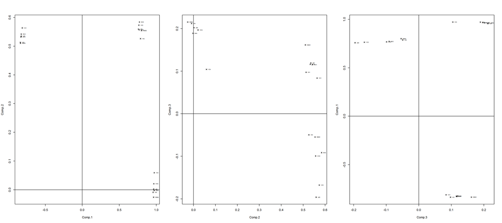

```r
par(mfrow = c(1, 3))
plot(fit$loadings[ ,'PC1'], fit$loadings[ ,'PC2'], type='p', pch=4, cex = 0.8, xlab='Comp.1', ylab='Comp.2')
text(fit$loadings[ ,'PC1'], fit$loadings[ ,'PC2'], colnames(train[ ,c(6:23)]), cex=.4, pos=4)
abline(h = 0)
abline(v = 0)
plot(fit$loadings[ ,'PC2'], fit$loadings[ ,'PC3'], type='p', pch=4, cex = 0.8, xlab='Comp.2', ylab='Comp.3')
text(fit$loadings[ ,'PC2'], fit$loadings[ ,'PC3'], colnames(train[ ,c(6:23)]), cex=.4, pos=4)
abline(h = 0)
abline(v = 0)
plot(fit$loadings[ ,'PC3'], fit$loadings[ ,'PC1'], type='p', pch=4, cex = 0.8, xlab='Comp.3', ylab='Comp.1')
text(fit$loadings[ ,'PC3'], fit$loadings[ ,'PC1'], colnames(train[ ,c(6:23)]), cex=.4, pos=4)
abline(h = 0)
abline(v = 0)
```

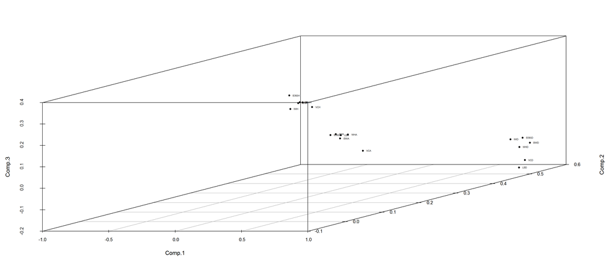

```r
par(mfrow = c(1, 1))
s3d <- scatterplot3d(fit$loadings[ ,'PC1'], fit$loadings[ ,'PC2'], fit$loadings[ ,'PC3'], xlab='Comp.1', ylab='Comp.2', zlab='Comp.3', pch = 20)
s3d.coords = s3d$xyz.convert(fit$loadings[ ,'PC1'], fit$loadings[ ,'PC2'], fit$loadings[ ,'PC3'])
text(s3d.coords$x, s3d.coords$y, labels=colnames(train[ ,c(6:23)]), cex=.4, pos = 4)
```

- For each variable in the plots above we can see loading components on each axis. We could rotate the axis so that each of the points pass through x, y and z axis. After rotating we would need to recompute the loading matrix. This is done by postmultiplying the unrotated loading matrix by a orthogonal transformation matrix.
- There are 3 types of rotational transformations we can employ. All these are all orthogonal rotations, that is, the axes remain perpendicular, so the components are not correlated with one another.
- **VARIMAX**: It is the most commonly used rotation. Its goal is to minimize the complexity of the components by making the large loadings larger and the small loadings smaller within each component.
- **QUARTIMAX**: Rotation makes large loadings larger and small loadings smaller within each variable.
- **EQUAMAX**: Rotation is a compromise that attempts to simplify both components and variables.  
  Note: There is a 4th type rotation method known as **OBLIQUE** rotation. But it doesn’t give orthogonal components.
- Used varimax rotational matrix for our analysis.

```r
fit <- principal(train[ ,c(6:23)], nfactors=18, rotate="varimax")
fit$loadings
```

```
##
## Loadings:
##       PC1    PC2    PC9    PC4    PC5    PC6    PC7    PC8    PC15
## B365H  0.968 -0.204
## B365D -0.197  0.940  0.176                              0.199
## B365A -0.652  0.564  0.483
## BWH    0.973 -0.165 -0.121
## BWD   -0.164  0.952  0.140                      -0.174
## BWA   -0.646  0.590  0.462
## IWH    0.957 -0.188 -0.140
## IWD   -0.207  0.905  0.163  0.334
## IWA   -0.637  0.572  0.472  0.118
## LBH    0.969 -0.170 -0.114
## LBD   -0.186  0.937                       0.284
## LBA   -0.634  0.585  0.478
## WHH    0.970 -0.175 -0.117
## WHD   -0.180  0.925  0.130         0.305
## WHA   -0.624  0.602  0.473
## VCH    0.972 -0.134 -0.144
## VCD   -0.177  0.951                              0.205
## VCA   -0.620  0.653  0.383                                     0.200
##       PC14   PC11   PC10   PC17   PC13   PC12   PC16   PC3    PC18
## B365H                                                  -0.115
## B365D
## B365A                       0.141
## BWH
## BWD
## BWA                                0.137
## IWH          -0.165
## IWD
## IWA   -0.104
## LBH                                      -0.136
## LBD
## LBA                  0.155
## WHH                                             -0.110
## WHD
## WHA    0.149
## VCH
## VCD
## VCA
##
##                  PC1   PC2   PC9   PC4   PC5   PC6   PC7   PC8  PC15  PC14
## SS loadings    8.254 7.554 1.462 0.135 0.105 0.096 0.075 0.052 0.045 0.034
## Proportion Var 0.459 0.420 0.081 0.008 0.006 0.005 0.004 0.003 0.002 0.002
## Cumulative Var 0.459 0.878 0.959 0.967 0.973 0.978 0.982 0.985 0.988 0.990
##                 PC11  PC10  PC17  PC13  PC12  PC16   PC3  PC18
## SS loadings    0.034 0.031 0.030 0.023 0.023 0.018 0.016 0.013
## Proportion Var 0.002 0.002 0.002 0.001 0.001 0.001 0.001 0.001
## Cumulative Var 0.991 0.993 0.995 0.996 0.997 0.998 0.999 1.000
```

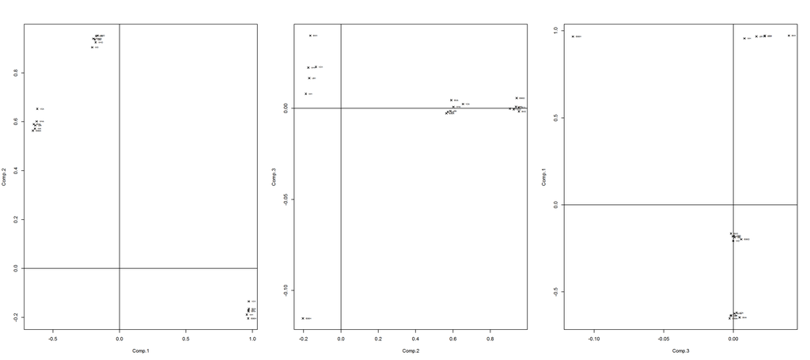

```r
par(mfrow = c(1, 3))
plot(fit$loadings[ ,'PC1'], fit$loadings[ ,'PC2'], type='p', pch=4, cex = 0.8, xlab='Comp.1', ylab='Comp.2')
text(fit$loadings[ ,'PC1'], fit$loadings[ ,'PC2'], colnames(train[ ,c(6:23)]), cex=.4, pos=4)
abline(h = 0)
abline(v = 0)
plot(fit$loadings[ ,'PC2'], fit$loadings[ ,'PC3'], type='p', pch=4, cex = 0.8, xlab='Comp.2', ylab='Comp.3')
text(fit$loadings[ ,'PC2'], fit$loadings[ ,'PC3'], colnames(train[ ,c(6:23)]), cex=.4, pos=4)
abline(h = 0)
abline(v = 0)
plot(fit$loadings[ ,'PC3'], fit$loadings[ ,'PC1'], type='p', pch=4, cex = 0.8, xlab='Comp.3', ylab='Comp.1')
text(fit$loadings[ ,'PC3'], fit$loadings[ ,'PC1'], colnames(train[ ,c(6:23)]), cex=.4, pos=4)
abline(h = 0)
abline(v = 0)
```

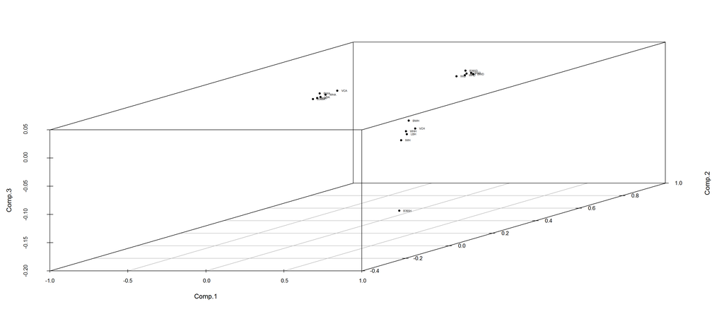

```r
par(mfrow = c(1, 1))
s3d <- scatterplot3d(fit$loadings[ ,'PC1'], fit$loadings[ ,'PC2'], fit$loadings[ ,'PC3'], xlab='Comp.1', ylab='Comp.2', zlab='Comp.3', pch = 20)

s3d.coords = s3d$xyz.convert(fit$loadings[ ,'PC1'], fit$loadings[ ,'PC2'], fit$loadings[ ,'PC3'])
text(s3d.coords$x, s3d.coords$y, labels=colnames(train[ ,c(6:23)]), cex=.4, pos = 4)
```

```r
train[ ,c('StrongHome', 'StrongDrawWeakAway', 'WeakDrawStrongAway')] <- data.matrix(train[ ,c(6:23)]) %*% data.matrix(fit$loadings[ ,c('PC1', 'PC2', 'PC3')])
test[ ,c('StrongHome', 'StrongDrawWeakAway', 'WeakDrawStrongAway')] <- data.matrix(test[ ,c(6:23)]) %*% data.matrix(fit$loadings[ ,c('PC1', 'PC2', 'PC3')])
final_test[ ,c('StrongHome', 'StrongDrawWeakAway', 'WeakDrawStrongAway')] <- data.matrix(final_test[ ,c(6:23)]) %*% data.matrix(fit$loadings[ ,c('PC1', 'PC2', 'PC3')])
```